# Why does rate-multiplier $T_{crit}$ disagree between lethal and sublethal endpoints?

Author

Patrice Pottier + Claude (Sonnet 4.6)

Published

May 13, 2026

## The observation

On the brown shrimp dataset, the rate-multiplier $T_{crit}$ posteriors from the lethal and sublethal pipelines disagree — their 95 % credible intervals do not overlap.

```r
tibble::tribble(
  ~Endpoint,                              ~`z (°C)`,                                 ~`CTmax_1hr (°C)`,                              ~`T_crit (°C)`,
  "Lethal 4PL (counts)",                  paste0(qd(posteriors$lethal$z), collapse = ", "),
                                          paste0(qd(posteriors$lethal$CTmax), collapse = ", "),
                                          paste0(qd(posteriors$lethal$Tcrit), collapse = ", "),
  "Sublethal 4PL (knocked-down)",         paste0(qd(posteriors$sublethal_4pl$z), collapse = ", "),
                                          paste0(qd(posteriors$sublethal_4pl$CTmax), collapse = ", "),
                                          paste0(qd(posteriors$sublethal_4pl$Tcrit), collapse = ", "),
  "Sublethal linear (log time)",          paste0(qd(posteriors$sublethal_linear$z), collapse = ", "),
                                          paste0(qd(posteriors$sublethal_linear$CTmax), collapse = ", "),
                                          paste0(qd(posteriors$sublethal_linear$Tcrit), collapse = ", ")
) |>
  knitr::kable(align = "lccc")
```

Table 1: Posterior medians and 95% credible intervals for the three pipelines, computed from the cached `output/models/*.rds` fits. The lethal fit uses `time_multiplier = 60` (model time in hours, t_ref = 60 min). The sublethal 4PL uses `time_multiplier = 1` (model time already in minutes), matching the supplement’s `extract_tdt()` call. The linear sublethal Tcrit is computed analytically from the linear-model posteriors using the same $r^*$ range.

| Endpoint | z (°C) | CTmax_1hr (°C) | T_crit (°C) |
| --- | --- | --- | --- |
| Lethal 4PL (counts) | 2.59, 2.29, 3.04 | 31.58, 30.52, 32.68 | 25.21, 23.13, 26.87 |
| Sublethal 4PL (knocked-down) | 1.11, 1.02, 1.22 | 31.42, 31.18, 31.69 | 28.68, 27.96, 29.31 |
| Sublethal linear (log time) | 1.1, 1, 1.23 | 31.47, 31.21, 31.75 | 28.72, 27.96, 29.39 |

Two things stand out.

- **$CT_{max_{1hr}}$ for the three pipelines is essentially the same** (lethal 31.58 °C, sublethal 4PL 31.42 °C, sublethal linear 31.47 °C). The 1-hour-50% temperature for “knocked down” and for “dead” sits at roughly the same place on the temperature axis on this panel.
- **$z$ is more than halved going from lethal to sublethal** (2.59 °C lethal → 1.11 °C sublethal). The two sublethal pipelines agree closely on $z$ and $CT_{max_{1hr}}$, so this is not an artefact of the 4PL aggregation; the sublethal log-time data really do have a steeper slope on $\log_{10}(\text{time})$ vs. $T$ than the lethal data do.

Plug those into $T_{crit} \approx CT_{max_{1hr}} - 2.5\,z$ (the posterior median of $T_{crit} = CT_{max_{1hr}} + z \cdot \log_{10}(r^*/100)$ with $r^*$ uniform on $\log_{10}$ across $[0.1, 1]$ % HI per hour) [Arnold *et al.* (2025); Jørgensen *et al.* (2021); **havro_faber_2023**] and you get the observed gap:

- Lethal: 31.58 − 2.5 × 2.59 ≈ 25.1 °C
- Sublethal: 31.42 − 2.5 × 1.11 ≈ 28.65 °C

So the gap is entirely driven by the difference in $z$, magnified 2.5× by the rate-multiplier formula.

## The TDT lines tell the same story

The cleanest way to see what is happening is to plot the predicted 1-hour-50% temperature across a temperature grid for each pipeline — i.e., the TDT line $\log_{10}(\text{time to endpoint}) = f(T)$. If both endpoints reflected the same underlying damage process with different manifestation thresholds, the two lines would be **parallel**, offset by a constant on the $\log_{10}$ axis. They are not.

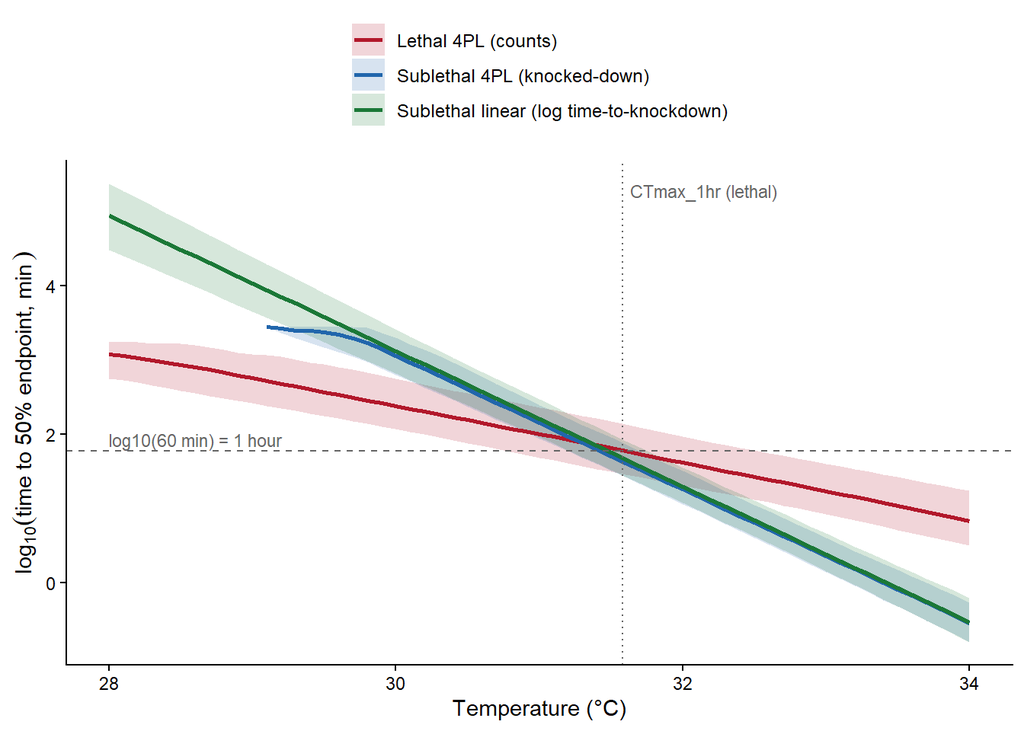

Figure 1: Posterior $\log_{10}$ (time to 50% endpoint) across temperature for the three shrimp pipelines. The horizontal dashed line is $\log_{10}(60)$ minutes = 1 hour; the vertical reference is the posterior median $CT_{max_{1hr}}$ from the lethal fit. Where each TDT line crosses the dashed line is its $CT_{max_{1hr}}$. The two sublethal pipelines agree across the panel temperature range, and both cross the lethal line at $\approx CT_{max_{1hr}}$. At lower temperatures the steeper sublethal line predicts *longer* times to knockdown than the lethal line predicts to death — biologically impossible — so the linearity assumption holds only over a narrow window near $CT_{max_{1hr}}$ and the two lines should not be extrapolated past the data.

```r
ct_let_med <- post_med(posteriors$lethal$CTmax)

ggplot(tdt_lines,
        aes(x = temp, y = log10_time_med, colour = method, fill = method)) +
  geom_ribbon(aes(ymin = log10_time_lo, ymax = log10_time_hi),
              alpha = 0.18, colour = NA) +
  geom_line(linewidth = 1) +
  geom_hline(yintercept = log10(60), linetype = "dashed",
             colour = "grey40") +
  geom_vline(xintercept = ct_let_med, linetype = "dotted",
             colour = "grey40") +
  annotate("text", x = min(tdt_lines$temp), y = log10(60),
           label = "log10(60 min) = 1 hour",
           hjust = 0, vjust = -0.3, size = 3, colour = "grey40") +
  annotate("text", x = ct_let_med, y = max(tdt_lines$log10_time_hi),
           label = "CTmax_1hr (lethal)",
           hjust = -0.05, vjust = 1, size = 3, colour = "grey40") +
  scale_colour_manual(values = c("Lethal 4PL (counts)" = "#b2182b",
                                  "Sublethal 4PL (knocked-down)" = "#2166ac",
                                  "Sublethal linear (log time-to-knockdown)" = "#1b7837")) +
  scale_fill_manual(values   = c("Lethal 4PL (counts)" = "#b2182b",
                                  "Sublethal 4PL (knocked-down)" = "#2166ac",
                                  "Sublethal linear (log time-to-knockdown)" = "#1b7837")) +
  labs(x = "Temperature (°C)",
       y = expression(log[10]("time to 50% endpoint, min")),
       colour = NULL, fill = NULL) +
  theme_classic() +
  theme(legend.position = "top",
        legend.direction = "vertical",
        legend.text = element_text(size = 9))
```

Three things to read off Figure 1:

1. **The two sublethal pipelines agree closely.** Both the joint 4PL on proportion-knocked-down and the classical linear regression on $\log_{10}$ times give essentially the same TDT line. The discrepancy with the lethal line is therefore a real feature of the data, not a 4PL-vs-linear artefact.
2. **The lethal and sublethal lines cross at $\approx CT_{max_{1hr}}$.** The posterior median lines intersect near the 1-hour duration right at the lethal $CT_{max_{1hr}}$ of 31.6 °C. At higher temperatures the lethal line predicts longer times than the sublethal — which is biologically sensible (knockdown precedes death). At lower temperatures the sublethal line predicts *longer* times to knockdown than the lethal line predicts to death — which is **biologically impossible**: an animal cannot die before it loses response to touch.
3. **Linearity breaks down outside the assay window.** The sublethal panel runs 31–33 °C; below 31 °C the line is pure extrapolation, and the extrapolation crosses through the lethal line and into the impossible region almost immediately. This is the classic warning against extrapolating a TDT line outside its assay range (Arnold *et al.* 2025; Jørgensen *et al.* 2021).

This is the underlying reason for the $T_{crit}$ disagreement. $T_{crit}$ in the rate-multiplier definition is computed by extrapolating each TDT line down to a low rate — but the sublethal TDT line is wrong in exactly the temperature range that extrapolation lands in. The lethal $T_{crit}$ at ~25 °C is itself an extrapolation, but at least one that stays in the region where ramping experiments (acclimation/recovery regimes) and the literature [**havro_faber_2023**] suggest the breakpoint sits. The sublethal $T_{crit}$ at ~28.7 °C sits on a TDT line that has *already crossed into the impossible region*.

## What does this say about $T_{crit}$?

Two related but distinct quantities are being conflated when we call both numbers “$T_{crit}$”:

1. **$T_{crit}$ as an extrapolated TDT-line quantity** — what `extract_tdt()` returns. It is the temperature at which the endpoint’s TDT line crosses a chosen rate floor $r^*$. The sublethal TDT line is steeper than the lethal one on this panel, so its $T_{crit}$ sits higher (closer to $CT_{max_{1hr}}$). This is mathematically correct given the input $(\hat z, \hat{CT}_{max})$ but the line being extrapolated is *demonstrably wrong* below the assay range (it predicts knockdown taking longer than death).
2. **$T_{crit}$ as a biological breakpoint** — Faber’s, Jørgensen’s definition. The temperature at which the absolute damage-rate function $r(T)$ stops following the $Q_{10} \sim 2$ permissive regime and starts the $Q_{10} \sim 100\text{--}25{,}000$ stressful regime [**havro_faber_2023**; Jørgensen *et al.* (2021)]. This is endpoint-agnostic: $r(T)$ is the same physiological process whether measured by knockdown or by death. It is detected empirically as a piecewise breakpoint in $\log(\text{rate})$ vs. $T$.

The current `extract_tdt()` computes (a), not (b), and labels it $T_{crit}$. **That is the source of the confusion**: (a) is *not* a good proxy for (b) unless the TDT line is approximately linear over the range $[T_{crit}^{(b)}, CT_{max_{1hr}}]$. For the lethal shrimp panel the line is well-behaved over that range and (a) lands in the right neighbourhood. For the sublethal shrimp panel the line is steeper at high $T$ and shallower at low $T$ (the data only see the high-$T$ limb), so extrapolating linearly produces a $T_{crit}$ that is biased upward — the line steepens just before $CT_{max_{1hr}}$ and the linear extrapolation continues that steep slope downward, missing the true (shallower) low-$T$ regime entirely.

## What is the “right” way to estimate $T_{crit}$?

Three options, in increasing order of how much they fix:

### 1. Stop pretending it is endpoint-agnostic

Keep the rate-multiplier $T_{crit}$ as the *operational* summary returned by `extract_tdt()`, but call it $T_{crit}^{(\text{endpoint}, r^*)}$ in the manuscript and never cross-compare lethal and sublethal values as if they were the same physiological threshold. This is the status quo plus honest labelling. It is the easiest change but it does not give us a single biologically defensible $T_{crit}$ for the species. We may want to make this clearer in the manuscript.

### 2. Compute Faber’s empirical breakpoint per posterior draw

For each posterior draw, take the fitted $\log_{10}\text{LT50}(T)$ curve over a *wide* temperature grid that spans both the permissive and stressful regimes. Fit a piecewise model (two segments meeting at a breakpoint, e.g. via `segmented::segmented()` or a brms piecewise-linear formula). The breakpoint location is the per-draw estimate of biological $T_c$. Pool across draws to get a posterior of $T_c$ that does **not** depend on the endpoint — the breakpoint of $\log(r(T))$ vs $T$ is the same physiological feature whether $r$ is “die-rate” or “knockdown-rate.”

There is one fundamental data requirement: the model has to have some support in the permissive regime ($T \lesssim T_c$, $Q_{10} \sim 2$). The shrimp panels do not: the lethal panel is 30–33 °C, all clearly above the expected $T_c \approx 25$ °C. So on this dataset the breakpoint would be entirely prior-driven for the lethal fit, and pure extrapolation for the sublethal fit. For future studies that aim to estimate $T_c$ specifically (rather than $CT_{max}$ at a reference duration), the design implication is clear: include at least one assay temperature below the expected $T_c$ and run it for long enough to see whether any death/knockdown accumulates.

### 3. Reframe $T_{crit}$ in absolute-damage units

If we had a calibration between the sublethal endpoint dose and the lethal endpoint dose (e.g., “50% knockdown corresponds to $\alpha$ fraction of the LT50 dose”), we could convert $r^*_{\text{sub}} = \alpha \cdot r^*_{\text{leth}}$ and bring both $T_{crit}$ values onto a common absolute-rate axis. This is biologically motivated but species- and endpoint-specific and beyond what we can do with the shrimp data alone. Worth a sentence in the discussion as a future direction.

## Recommendation for the current manuscript

The supplement now contains an explicit caveat (*A caution on cross-endpoint comparison of $T_{crit}$* in the shrimp sublethal section) that the rate-multiplier $T_{crit}$ is endpoint-conditional and should not be cross-compared between lethal and sublethal fits without that adjustment. We should keep that caveat. In the discussion of the manuscript we should:

- Acknowledge that the rate-multiplier $T_{crit}$ as implemented is the extrapolated-TDT-line variant (a), not the empirical breakpoint (b), and that the two only coincide when the TDT line is roughly linear over $[T_c, CT_{max_{1hr}}]$.
- Recommend that future TDT designs aimed at $T_c$ include at least one permissive-range assay temperature.
- Flag option 2 (piecewise breakpoint per draw) as the natural extension for datasets that do have permissive-range data.

## Open follow-ups

See also [[reference_faber_2023_tcrit]] and the earlier note `2026-05-12-tcrit-reconsidered-faber-et-al.qmd`.

## References

Arnold, P.A., Noble, D.W.A., Nicotra, A.B., Kearney, M.R., Rezende, E.L., Andrew, S.C., *et al.* (2025). [A framework for modelling thermal load sensitivity across life](https://doi.org/10.1111/gcb.70315). *Global Change Biology*, 31, e70315.

Jørgensen, L.B., Malte, H. & Overgaard, J. (2021). [A unifying model to estimate thermal tolerance limits in ectotherms across static, dynamic and fluctuating exposures to thermal stress](https://doi.org/10.1038/s41598-021-92004-6). *Scientific Reports*, 11, 12840.